# Advanced Classification - Part 5

One should look for what is and not what he thinks should be. (Albert Einstein)

# Module completion checklist

| Objective | Complete |
| --- | --- |
| Introduce the concept of a hyperplane and classification using a hyperplane |  |
| Summarize the idea of maximal margin classifier and its pitfalls |  |
| Explain the concept of support vectors and build a support vector classifier model |  |

# Support Vector Machines

- We have studied ensemble methods like Random Forest and Gradient Boosting Models for classification
- Every dataset is different and no one classification algorithm is a best fit for all types of datasets
- What if you have **high dimensional data** at work and you have to classify a target variable?
- What if your dataset contains more **categorical variables?**
- Today, we will learn about Support vector machines:
  - a machine learning algorithm which was developed to handle such issues in our dataset

# Concept behind different classifiers

- We studied many classification algorithms so far
  - Trees and ensemble methods classify based on the value of predictors using the idea of segmentation
- The model we are going to study today makes use of a hyperplane to classify the observations

# Idea behind SVM as a classifier

- Support vector machines build the model by creating a **feature space** which is a finite dimensional vector space
- Each dimension represents the features which we are using to predict the target
- SVM creates a **hyperplane which creates a linear partition of the feature space into two categories**
- The target is classified into two categories based on whether the features lie above or below the hyperplane

# What is a hyperplane?

- In a `p` dimensional space, a **hyperplane is a flat subspace of dimension `p-1`**
- In two dimensions, a hyperplane is a flat one dimensional subspace which is a **line**
- In three dimensions, a hyperplane is a flat two dimensional subspace which is a plane
- For `p > 3` dimensions, it’s hard to visualize, but there are still `p-1` dimensional flat subspaces
- A hyperplane divides the `p` dimensional space into two halves

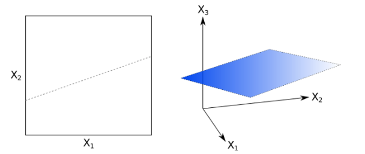

# Optimal hyperplane

- Our main goal is to develop a classifier which has a hyperplane that perfectly classifies our data into two classes
- There could be a **infinite number of hyperplanes** that perfectly separate the classes, but we want an optimal hyperplane that perfectly separates the classes

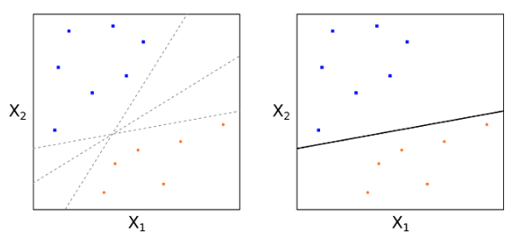

# Maximal margin classifier

- We need to find an optimal hyperplane or a **maximal margin hyperplane** from the set of infinite hyperplanes
- We compute the perpendicular distance from each training observation for a given separating hyperplane

# Maximal margin classifier

- The smallest perpendicular distance to a training observation from the hyperplane is known as the **margin**
- We use optimization methods to maximize this margin
- The maximal margin hyperplane is the hyperplane where the margin is the largest
- Such a classifier is known as **maximal margin classifier (MMC)**

# Support vectors

# Pitfalls in MMC - no perfectly separating hyperplane

- MMC is a natural way to perform classification only if a natural hyperplane which perfectly separates the two classes exists
- But do you think that all the real life datasets are perfectly separable?
- In most real life cases, a perfectly separating hyperplane will not exist
- In such cases, we cannot use a maximal margin classifier

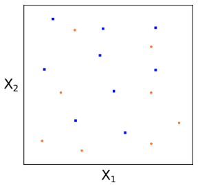

# Pitfalls in MMC - overfitting

- Even when a perfectly separating hyperplane does exist, there are instances where it may not be desirable
- This method has a high potential to overfit, because it perfectly fits the data and is highly sensitive to only few training observations

# Knowledge check 1

# Warm up

- Before we start, check out this video about AI in the medical field: [link](https://www.youtube.com/watch?v=G1IsZeFR_Rk)

# Welcome back!

- In the previous session we have covered ensemble methods like Random Forest, Gradient Boosting Models for classification and the concepts of hyperplanes and Support Vector Machines
- Today we will start looking into:
  - differences between support vector classifier and support vector machine
  - building a support vector machine
  - using grid search to optimize SVM

# Module completion checklist

| Objective | Complete |
| --- | --- |
| Introduce the concept of a hyperplane and classification using a hyperplane | **✔** |
| Summarize the idea of maximal margin classifier and its pitfalls | **✔** |
| Explain the concept of support vectors and build a support vector classifier model |  |

# Loading packages

- Let’s load the packages we will be using
- These packages are used for classification in SVM

```python
import os
import pickle
import numpy as np
import pandas as pd
import matplotlib.pyplot as plt
from pathlib import Path
from sklearn.model_selection import train_test_split
from sklearn.svm import SVC
from sklearn import metrics
from sklearn.model_selection import GridSearchCV
```

# Support vector classifier

- To overcome the pitfalls of maximal margin classifier, we might be willing to consider a classifier based on a hyperplane that does not perfectly separate the two classes
- This will help add greater robustness to individual observations and improve classification of the observation
- It could be worth it to **misclassify a few training observations** in order to do a better job in classifying the remaining observations
- This classifier is called a support vector classifier or **soft margin classifier**

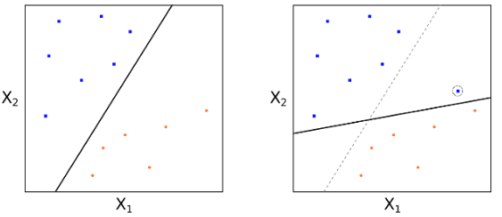

# Tuning parameters

- There are three tuning parameters to get a optimal hyperplane for classification using a soft margin classifier
  - **Non-negative tuning parameter (aka cost function)** $C$ which determines the severity of misclassification
  - **Margin width** $M$ which we want to make as large as possible
  - **Slack variables** $\epsilon_i$ which we will talk about next

# Slack variables

- Slack variables $\epsilon_i$ are the variables that allow the observations on the wrong side of the hyperplane
- $\epsilon_i$ tells us where the *`i`*th observation is located relative to the hyperplane and relative to the margin
- If $\epsilon_i = 0$, then the *`i`*th observation is on the **correct side of the margin**
- If $1 > \epsilon_i > 0$, then the *`i`*th observation is on the wrong side of the margin
- If $\epsilon_i >= 1$, then the *`i`*th observation is on the **wrong side of the hyperplane**

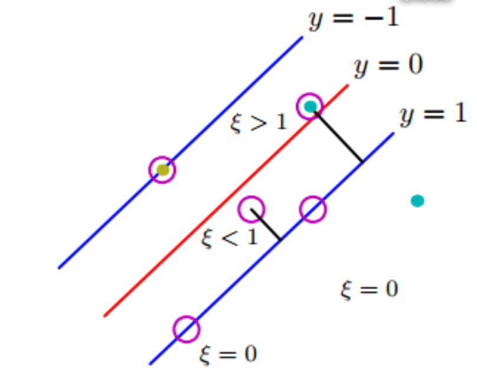

# Cost function C

# Support vectors in SVC

- The observations that either lie on the margin or that violate the margin will affect the hyperplane
- The observations that lie clearly on the correct side of the margin do not affect the classifier
- The observations that lie on the wrong side of the margin drive the classifier and affect the hyperplane and those points are called support vectors

# Building a Support vector classifier model

- We already used our `Costa Rican` dataset and classified the poverty levels of the individuals
- Today, we will determine whether a person is classified as **poor or not** based on the information we have about that person’s living conditions and educational qualifications
- We will build a Support vector classifier model and discuss Support vector machine

# Review data cleaning steps

- **Today, we will be loading the cleaned dataset we used in last class**
- To recap, the steps to get to this cleaned dataset were:
  - Remove household ID and individual ID
  - Remove variables with over 50% NAs
  - Transformed target variable to binary
  - Remove highly correlated variables

# Directory settings

- In order to maximize the efficiency of your workflow, you should encode your directory structure into `variables`
- We will use the `pathlib` library
- Let the `main_dir` be the variable corresponding to your `course` folder
- Let `data_dir` be the variable corresponding to your `data` folder

```python
# Set 'main_dir' to location of the project folder
home_dir = Path(".").resolve()
main_dir = home_dir.parent.parent
print(main_dir)
```

```python
data_dir = str(main_dir) + "/data"
print(data_dir)
```

# Load the cleaned dataset

- Let’s load the pickled dataset, `costa_clean`
- Save it as `costa_clean`

```python
costa_clean = pickle.load(open((data_dir + "/costa_clean.sav"),"rb"))
```

```python
# Print the head.
print(costa_clean.head())
```

```
   rooms  tablet  males_under_12  ...  rural_zone  age  Target
0      3       0               0  ...           0   43    True
1      4       1               0  ...           0   67    True
2      8       0               0  ...           0   92    True
3      5       1               0  ...           0   17    True
4      5       1               0  ...           0   37    True

[5 rows x 81 columns]
```

# Print info on data

- Let’s view the column names

```python
# Print the columns.
costa_clean.columns
```

```
Index(['rooms', 'tablet', 'males_under_12', 'males_over_12', 'males_tot',
       'females_under_12', 'females_over_12', 'females_tot', 'ppl_under_12',
       'ppl_over_12', 'ppl_total', 'years_of_schooling', 'wall_block_brick',
       'wall_socket', 'wall_prefab_cement', 'wall_wood', 'floor_mos_cer_terr',
       'floor_cement', 'floor_wood', 'ceiling', 'electric_public',
       'electric_coop', 'toilet_sewer', 'toilet_septic', 'cookenergy_elec',
       'cookenergy_gas', 'trash_truck', 'trash_burn', 'wall_bad', 'wall_reg',
       'wall_good', 'roof_bad', 'roof_reg', 'roof_good', 'floor_bad',
       'floor_reg', 'floor_good', 'disabled_ppl', 'male', 'female', 'under10',
       'free', 'married', 'separated', 'single', 'hh_head', 'hh_spouse',
       'hh_child', 'num_child', 'num_adults', 'num_65plus', 'num_hh_total',
       'dependency_rate', 'male_hh_head_educ', 'female_hh_head_educ',
       'meaneduc', 'educ_none', 'educ_primary_inc', 'educ_primary',
       'educ_secondary_inc', 'educ_secondary', 'educ_undergrad', 'bedrooms',
       'ppl_per_room', 'house_owned_full', 'house_owned_paying',
       'house_rented', 'house_other', 'computer', 'television',
       'num_mobilephones', 'region_central', 'region_Chorotega',
       'region_pacifico', 'region_brunca', 'region_antlantica',
       'region_huetar', 'urban_zone', 'rural_zone', 'age', 'Target'],
      dtype='object')
```

# Split into training and test sets

```python
# Select the predictors and target.
X = costa_clean.drop(['Target'], axis = 1)
y = np.array(costa_clean['Target'])

# Set the seed to 1.
np.random.seed(1)

# Split into training and test sets with 70% train and 30% test.
X_train, X_test, y_train, y_test = train_test_split(X, y, test_size = 0.3)
```

# Support vector function in sklearn

- We will use the `svm.svc` function from the `sklearn` package to build our support vector classifier
- Find detailed documentation [here](https://scikit-learn.org/stable/modules/generated/sklearn.svm.SVC.html)

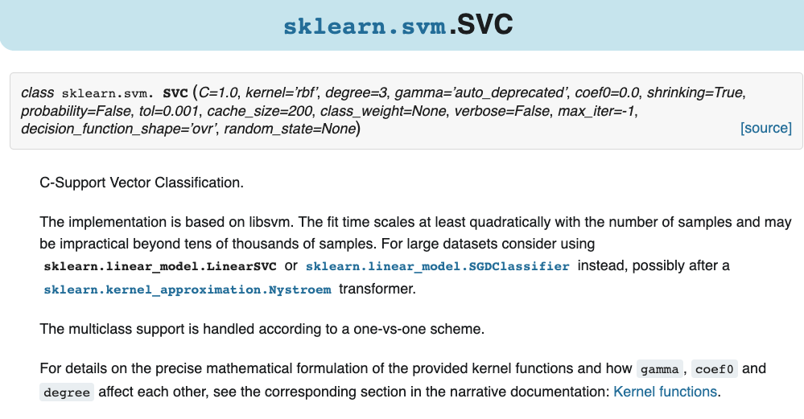

# Support vector function in sklearn

- The main arguments of the function are :
  - `C` : Non-negative tuning parameter (aka cost function)
  - `kernel` : Specifies the kernel type to be used in the algorithm (We will use `linear` for SVC and one of the other types for SVM)
  - `gamma` : the value which controls the shape of the kernel (We will talk more about this when we build an SVM)
  - `probability` : whether to enable probability estimates

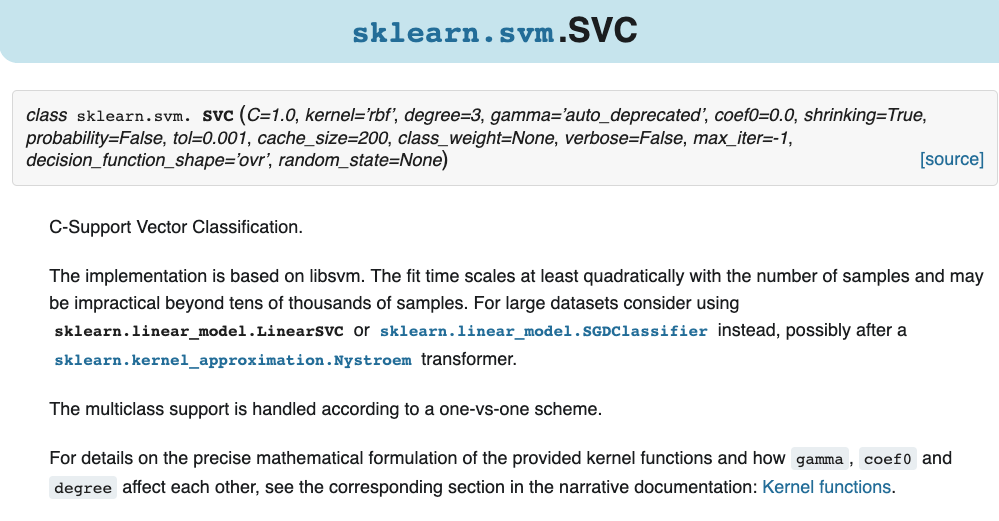

# Support vector classifier model

- Let’s train our model using `X_train` and `y_train`
- We will use the default value of `C`, which is 1
- Linear kernel specifies to create a linear hyperplane in the support vector classifier

```python
# Create an SVC classifier.
svclassifier = SVC(kernel = 'linear',
                   probability = True)

# Fit the model.
svclassifier.fit(X_train, y_train)
```

```
SVC(kernel='linear', probability=True)
```

# Recap: score evaluation function

- In the last module, we used a function to wrap all performance score calculations into one block of code which can be called repeatedly
- We will use this function to evaluate our SVM models today

```python
def get_performance_scores(y_test, y_predict, y_predict_prob, eps=1e-15, beta=0.5):
    from sklearn import metrics
    # Scores keys.
    metric_keys = ["accuracy", "precision", "recall", "f1", "fbeta", "log_loss", "AUC"]
    # Score values.
    metric_values = [None]*len(metric_keys)
    metric_values[0] = metrics.accuracy_score(y_test, y_predict)
    metric_values[1] = metrics.precision_score(y_test, y_predict)
    metric_values[2] = metrics.recall_score(y_test, y_predict)
    metric_values[3] = metrics.f1_score(y_test, y_predict)
    metric_values[4] = metrics.fbeta_score(y_test, y_predict, beta=beta)
    metric_values[5] = metrics.log_loss(y_test, y_predict_prob[:, 1], eps=eps)
    metric_values[6] = metrics.roc_auc_score(y_test, y_predict_prob[:, 1])
    perf_metrics = dict(zip(metric_keys, metric_values))
    return(perf_metrics)
```

# Predict on the test dataset

```python
# Predict on the test dataset.
svc_y_predict = svclassifier.predict(X_test)
svc_y_predict[0:5]

#Predict on test, but instead of labels
# we will get probabilities for class 0 and 1.
```

```
array([ True, False,  True,  True,  True])
```

```python
svc_y_predict_prob = svclassifier.predict_proba(X_test)
print(svc_y_predict_prob[5:])
```

```
[[0.56316354 0.43683646]
 [0.02540825 0.97459175]
 [0.00935204 0.99064796]
 ...
 [0.20868202 0.79131798]
 [0.84090023 0.15909977]
 [0.75329657 0.24670343]]
```

# Predict on the test dataset

```python
svc_scores = get_performance_scores(y_test, svc_y_predict, svc_y_predict_prob)
print(svc_scores)
```

```
{'accuracy': 0.7894002789400278, 'precision': 0.8085215605749486, 'recall': 0.872093023255814, 'f1': 0.8391049547149706, 'fbeta': 0.82048343404876, 'log_loss': 0.45829399974895174, 'AUC': 0.8533430102212127}
```

- As we can see, our SVC model performed moderately on all fronts

# Precision vs recall curve: the tradeoff

- Plot precision vs recall curve for the SVC model

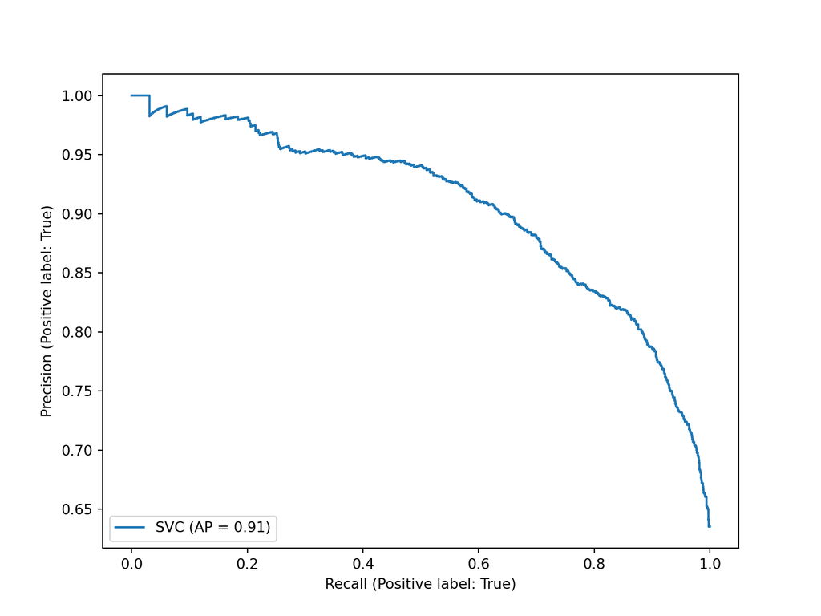

```python
svc_prec_recall = metrics.plot_precision_recall_curve(svclassifier,
                               X_test, y_test,
                               name = "SVC")
plt.show()
```

# ROC curve: the tradeoff

- Plot ROC curve for the SVC model

```python
svc_roc = metrics.plot_roc_curve(svclassifier,
                                X_test,
                                y_test,
                                name = "SVC")
plt.show()
```

- The AUC for this curve is about 85%, which is not bad, but we can do better

[figure not shown]

# Save final metrics of SVC

- **Let’s save our svc score in our `metrics_svm` dataset**
- We first have to load our `metrics_gbm` dataframe which we created previously

```python
metrics_svm = pickle.load(open((data_dir + "/metrics_gbm.sav"),"rb"))
```

# Save final metrics of SVC

```python
# Add the model to our dataframe.
metrics_svm.update({"SVC": svc_scores})
print(metrics_svm)
```

```
{'RF': {'accuracy': 0.9483960948396095, 'precision': 0.9447424892703863, 'recall': 0.9750830564784053, 'f1': 0.9596730245231607, 'fbeta': 0.9506586050529044, 'log_loss': 0.21947942349408847, 'AUC': 0.986855647527701}, 'Optimized RF': {'accuracy': 0.9483960948396095, 'precision': 0.9400212314225053, 'recall': 0.9806201550387597, 'f1': 0.9598915989159891, 'fbeta': 0.9478698351530723, 'log_loss': 0.21667604220201855, 'AUC': 0.9876901226920936}, 'GBM': {'accuracy': 0.8291492329149233, 'precision': 0.8374358974358974, 'recall': 0.9042081949058693, 'f1': 0.869542066027689, 'fbeta': 0.8499895898396836, 'log_loss': 0.39102395649143923, 'AUC': 0.902052011186816}, 'Optimized GBM': {'accuracy': 0.9592050209205021, 'precision': 0.9678670360110804, 'recall': 0.9673311184939092, 'f1': 0.9675990030462477, 'fbeta': 0.9677598050077555, 'log_loss': 0.5621060823499561, 'AUC': 0.9918591095177615}, 'SVC': {'accuracy': 0.7894002789400278, 'precision': 0.8085215605749486, 'recall': 0.872093023255814, 'f1': 0.8391049547149706, 'fbeta': 0.82048343404876, 'log_loss': 0.45829399974895174, 'AUC': 0.8533430102212127}}
```

- SVC metrics are lower than ensemble methods on almost all fronts because, in most cases, ensemble of classifiers tend to outperform a single classifier

# Knowledge check 2

# Exercise 1

# Module completion checklist

| Objective | Complete |
| --- | --- |
| Introduce the concept of a hyperplane and classification using a hyperplane | **✔** |
| Summarize the idea of maximal margin classifier and its pitfalls | **✔** |
| Explain the concept of support vectors and build a support vector classifier model | **✔** |

# Congratulations on completing this module!